# 08.Example 2

## Given:

Water flows at a velocity $u_\infty = 1 \frac{m}{s}$ over a flat plate of length $L = 0.6 m$. Consider two cases, one for which the water temperature is approximately $300 K$ and the other for an approximate water temperature of $350 K$. In the laminar and turbulent regions, experimental measurements show that the local convection coefficients are well described by  
$h_{lam}\left(x\right)=C_{lam}x^{-0.5}$  
$h_{tur}\left(x\right)=C_{tur}x^{-0.2}$  
where $x$ has units of $m$. At $300 K$,  
$C_{lam,300}=395 \frac{W}{m^{1.5}K}$  
$C_{tur,300}=2330 \frac{W}{m^{1.8}K}$  
while at $350 K$,  
$C_{lam,350}=477 \frac{W}{m^{1.5}K}$  
$C_{tur,350}=3600 \frac{W}{m^{1.8}K}$  
As is evident, the constant $C$ depends on the nature of the flow as well as the water temperature because of the thermal dependence of various properties of the fluid.

## Required:

Determine the average convection coefficient, $\bar{h}$, over the entire plate for the two water temperatures. Plot the convective coefficients as a function of $x$ for the entire length of the flat plate. On the plot, show the average convective coefficient values.

## Solution:

Start first by importing any needed libraries.

```python
import matplotlib.pyplot as plt
import numpy as np
import pint # https://pint.readthedocs.io
```

The unit registry may then be defined. This is shown below.

```python
ureg=pint.UnitRegistry()
ureg.setup_matplotlib()
Q_=ureg.Quantity
```

The given problem variables may now be defined with units.

```python
u_inf=Q_(1, 'm/s')
L=Q_(0.6, 'm')
C_lam300=Q_(395, 'W/(m**1.5*K)')
C_tur300=Q_(2330, 'W/(m**1.8*K)')
C_lam350=Q_(477, 'W/(m**1.5*K)')
C_tur350=Q_(3600, 'W/(m**1.8*K)')
```

The given functions for the convective coefficients may be defined as Python functions to aid in calculating the values and when plotting. This is shown below.

```python
def h_lamFunc(C, x):
    return C*x**-0.5

def h_turFunc(C, x):
    return C*x**-0.2
```

The density $\rho$ and dynamic viscosity $\mu$ of water needs to be used and may be found in Table A.6. Table A.6 does not have density values but it does have specific volume. From Table A.6, the specific volume $\nu$ and dynamic viscosity $\mu$ at $300K$ and $350K$ are defined below.

```python
v_f300=Q_(1.003E-3, 'm**3/kg')
mu_300=Q_(855E-6, 'N*s/m**2')
v_f350=Q_(1.027E-3, 'm**3/kg')
mu_350=Q_(365E-6, 'N*s/m**2')
```

The density values may then be found by taking the inverse of the specific volume. This is shown below.

```python
rho_300=1/v_f300
round(rho_300, 1)
```

997.0 kilogram/meter<sup>3</sup>

```python
rho_350=1/v_f350
round(rho_350, 1)
```

973.7 kilogram/meter<sup>3</sup>

For a flat plate, the critical Reynolds number is $Re_{x,c}=5 \times 10^5$. This is defined below.

```python
Re_xc=5E5
```

The critical Reynolds number may be used to determine the critical location $x_c$. The definition of the Reynolds number is shown below.  
$Re_{x}=\frac{\rho u_\infty x}{\mu}$  
Solving for the critical location, the Reynolds number definition becomes  
$x_c=\frac{Re_{x,c}\mu}{\rho u_\infty}$

```python
x_c300=Re_xc*mu_300/(rho_300*u_inf)
round(x_c300.to('m'), 4)
```

0.4288 meter

```python
x_c350=Re_xc*mu_350/(rho_350*u_inf)
round(x_c350.to('m'), 4)
```

0.1874 meter

The average convective coefficient $\bar{h}$ value is given by  
$\bar{h}=\frac{1}{L} \int_0^L h\left(x\right) dx$  
However, the local convective coefficient $h$ is not a single function for the length of $L$. The integral must be broken into two parts to account for the laminar and turbulent portion. This is shown below.  
$\bar{h}=\frac{1}{L}\left( \int_0^{x_c} h_{lam}\left(x\right) dx + \int_{x_c}^L h_{tur}\left(x\right) dx\right)$  
These two integrals may now be evaluated for each of their limits. This is shown below.  
$\bar{h}=\frac{1}{L}\left[ \frac{C_{lam}}{0.5}x_c^{0.5} + \frac{C_{tur}}{0.8} \left(L^{0.8} - x_c^{0.8} \right)\right]$

```python
hb_300=(1/L)*((C_lam300/0.5)*x_c300**0.5+(C_tur300/0.8)*(L**0.8-x_c300**0.8))
round(hb_300.to('kW/(m**2*K)'), 3)    # answer to first part
```

1.622 kilowatt/(kelvin meter<sup>2</sup>)

```python
hb_350=(1/L)*((C_lam350/0.5)*x_c350**0.5+(C_tur350/0.8)*(L**0.8-x_c350**0.8))
round(hb_350.to('kW/(m**2*K)'), 3)    # answer to first part
```

3.708 kilowatt/(kelvin meter<sup>2</sup>)

The plotting values for $x$ and the $h$ terms will be created using [Numpy's](https://docs.scipy.org/doc/numpy/index.html) linspace. This is shown below.

```python
x_lam300=np.linspace(0.01, x_c300.to('m').magnitude, 100)*ureg.m
x_tur300=np.linspace(x_c300.to('m').magnitude, L.to('m').magnitude, 100)*ureg.m
x_300=np.concatenate([x_lam300.to('m').magnitude, x_tur300.to('m').magnitude])*ureg.m

x_lam350=np.linspace(0.01, x_c350.to('m').magnitude, 100)*ureg.m
x_tur350=np.linspace(x_c350.to('m').magnitude, L.to('m').magnitude, 100)*ureg.m
x_350=np.concatenate([x_lam350.to('m').magnitude, x_tur350.to('m').magnitude])*ureg.m

h_lam300=h_lamFunc(C_lam300, x_lam300)
h_tur300=h_turFunc(C_tur300, x_tur300)
h_300=np.concatenate([h_lam300.to('W/(m**2*K)').magnitude, h_tur300.to('W/(m**2*K)').magnitude])
h_300=h_300*(ureg.W)/(ureg.m**2*ureg.K)

h_lam350=h_lamFunc(C_lam350, x_lam350)
h_tur350=h_turFunc(C_tur350, x_tur350)
h_350=np.concatenate([h_lam350.to('W/(m**2*K)').magnitude, h_tur350.to('W/(m**2*K)').magnitude])
h_350=h_350*(ureg.W)/(ureg.m**2*ureg.K)
```

As of this writing, it appears that there is a bug in the Pint library that causes an error when trying to plot with units. See [here](https://github.com/hgrecco/pint/issues/760) for status of bug. To avoid this, the units will be removed and the unitless values will be plotted. Removing the units is shown below.

```python
x_300=x_300.to('m').magnitude
h_300=h_300.to('W/(m**2*K)').magnitude

x_350=x_350.to('m').magnitude
h_350=h_350.to('W/(m**2*K)').magnitude
```

The plotting handle may now be created and plotting elements added to the plot. This is shown below.

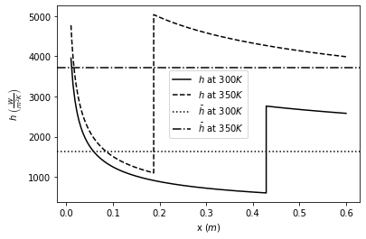

```python
fig, ax=plt.subplots(1, 1)

ax.plot(x_300, h_300, color='k', label='$h$ at $300 K$')
ax.plot(x_350, h_350, color='k', linestyle='dashed', label='$h$ at $350 K$')

ax.set_xlabel('x $\\left(m\\right)$')
ax.set_ylabel('$h\\ \\left( \\frac{W}{m^2 K}\\right)$')

ax.axhline(hb_300.to('W/(m**2*K)').magnitude, color='k', linestyle='dotted', label='$\\bar{h}$ at $300 K$')
ax.axhline(hb_350.to('W/(m**2*K)').magnitude, color='k', linestyle='dashdot', label='$\\bar{h}$ at $350 K$')

ax.legend()

plt.show()
```

Download Complete Python Script Here